# Trabajo Final

Juan Carlos Trejos

2 de diciembre de 2020

### Repositorio

[GitHub](https://github.com/juash10/NP_analisis)

## Pregunta de investigación

Como aún no está claro cuál de los nutrientes principales (N o P) es el factor limitante en la productividad primaria neta de los bosques tropicales, se realizó un experimento de fertilización *in situ* de más de 12 años en un bosque tropical de bajura en el Caribe de Costa Rica, específicamente en la reserva de la Universidad EARTH (Alvarez-Clare, Mack, and Brooks 2013). Tradicionalmente se ha propuesto que el fósforo es el factor limitante en estos ecosistemas por su baja disponibilidad, debido a la alta meteorización en estos ambientes.

Lo que se busca con este experimento es determinar el efecto que tiene la adición de estos nutrientes en la actividad microbiana del suelo en estos bosques, ya que no se tiene claro cuál es el factor limitante en la productividad de estos ecosistemas. Además, se quiere conocer en qué momento se da el pico de actividad posterior a la adición de nutrientes.

Para esto, se realizaron mediciones in situ del flujo de CO2 proveniente del suelo antes de la fertilización, a las 24h, 72h y a los 9 días, en el año 2017. Se realizó además un diseño en seis bloques aleatorizados de las parcelas definidas por el nutriente añadido (N: nitrógeno, P: fósforo, NP: combinación de ambos, y C: control), en cada uno de dos sectores de la reserva.

## DAG

El flujo de CO2 producido por la microbiota del suelo es influenciado por el tipo de nutriente añadido y el tiempo transcurrido desde su adición.

```r
# Carga de librerías
require(dagitty)
require(ggdag)

# Definición del DAG
dag <- dagify(CO2 ~ Tiempo,
              CO2 ~ Nutr,
              exposure = "Nutr",
              outcome = "CO2")
tidy_dagitty(dag)
```

```
## # A DAG with 3 nodes and 2 edges
## #
## # Exposure: Nutr
## # Outcome: CO2
## #
## # A tibble: 3 x 8
##   name       x     y direction to     xend  yend circular
##   <chr>  <dbl> <dbl> <fct>     <chr> <dbl> <dbl> <lgl>
## 1 Nutr    24.1  36.7 ->        CO2    24.7  35.8 FALSE
## 2 Tiempo  25.4  34.8 ->        CO2    24.7  35.8 FALSE
## 3 CO2     24.7  35.8 <NA>      <NA>   NA    NA   FALSE
```

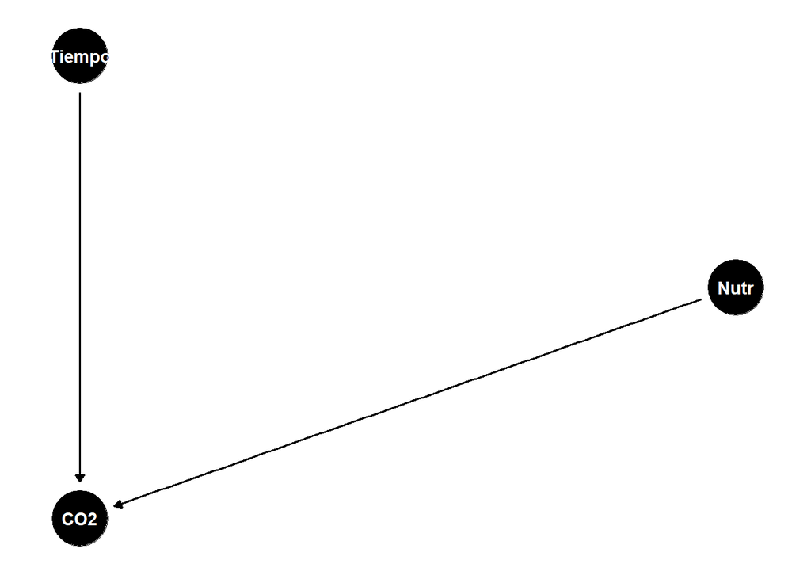

```r
ggdag(dag, layout = "circle") + theme_dag()
```

## Base de Datos

```r
# Definición del directorio
setwd("C:/Users/JC/Desktop/Trabajo_Final")
# Base de datos crudos
dat <- read.csv("datos_crudos.csv", sep = ";", dec = ",")
head(dat)
```

```
##   Tratamiento trat bloque plot            date label obs exp.flux    t1    v1
## 1         pre    N      1    1 23/4/2017 15:33     a  60     6.31 26.13 1.910
## 2         pre    N      1    1 23/4/2017 15:36     a  61     5.55 26.05 1.911
## 3         pre    N      1    1 23/4/2017 15:39     a  62     5.74 26.02 1.912
## 4         pre    N      1    1 23/4/2017 15:48     d  63     5.12 26.02 2.364
## 5         pre    N      1    1 23/4/2017 15:51     d  64     5.23 25.92 2.370
## 6         pre    N      1    1 23/4/2017 15:54     d  65     5.08 25.91 2.374
##       v4 soilmo.perc tcham pressure    h20    co2   cdry    rh tbench fitstatus
## 1 28.359        54.5 28.34    98.98 34.438 497.32 515.06 88.05  51.50     Exp 3
## 2 28.220        54.5 28.27    98.99 34.728 534.29 553.52 89.19  51.50       Lin
## 3 28.062        54.5 28.17    99.00 34.063 498.63 516.22 88.02  51.52     Exp 2
## 4 28.185        54.2 28.11    99.04 34.030 482.79 499.80 88.23  51.52       Lin
## 5 28.178        54.2 28.03    99.04 34.065 488.09 505.30 88.75  51.51     Exp 2
## 6 28.134        54.2 27.97    99.05 33.480 467.16 483.34 87.48  51.51       Lin
##   licor
## 1     1
## 2     1
## 3     1
## 4     1
## 5     1
## 6     1
```

```r
# Base de datos sin variables no importantes y sin datos de agosto porque corresponden a otro experimento
dat1 <- dat[,-c(5:7,9:21)]
head(dat1)
```

```
##   Tratamiento trat bloque plot exp.flux
## 1         pre    N      1    1     6.31
## 2         pre    N      1    1     5.55
## 3         pre    N      1    1     5.74
## 4         pre    N      1    1     5.12
## 5         pre    N      1    1     5.23
## 6         pre    N      1    1     5.08
```

```r
names(dat1) <- c("Tiempo","Tratamiento","Bloque","Parcela","Flujo_CO2")
# Ordenando los factores
levels(dat1$Tiempo)
```

```
## [1] ""    "24h" "72h" "9d"  "pre"
```

```r
dat1$Tiempo <- factor(dat1$Tiempo,
                          ordered = TRUE,
                          levels = c("pre", "24h", "72h", "9d"))
levels(dat1$Tratamiento)
```

```
## [1] ""   "C"  "N"  "NP" "P"
```

```r
dat1$Tratamiento <- factor(dat1$Tratamiento,
                          ordered = TRUE,
                          levels = c("C", "N", "NP", "P"))
```

## Análisis de Datos

```r
# Carga de librerías
require(ggplot2)
require(lme4)
require(plyr)

# Modelo con interacción porque hay una influencia distinta del tiempo sobre cada tratamiento de nutrientes
M.int <- lm(Flujo_CO2 ~ Tratamiento * Tiempo, data = dat1)
summary(M.int)
```

```
##
## Call:
## lm(formula = Flujo_CO2 ~ Tratamiento * Tiempo, data = dat1)
##
## Residuals:
##     Min      1Q  Median      3Q     Max
## -3.7838 -0.9581 -0.3363  0.5412  8.5979
##
## Coefficients:
##                        Estimate Std. Error t value Pr(>|t|)
## (Intercept)             4.96925    0.05977  83.145  < 2e-16 ***
## Tratamiento.L           0.12900    0.11645   1.108 0.268327
## Tratamiento.Q          -1.16682    0.11953  -9.762  < 2e-16 ***
## Tratamiento.C           0.43890    0.12253   3.582 0.000362 ***
## Tiempo.L               -0.33123    0.11974  -2.766 0.005799 **
## Tiempo.Q               -0.66693    0.11953  -5.579 3.30e-08 ***
## Tiempo.C                0.62029    0.11933   5.198 2.56e-07 ***
## Tratamiento.L:Tiempo.L  0.26679    0.23355   1.142 0.253653
## Tratamiento.Q:Tiempo.L  0.20088    0.23947   0.839 0.401803
## Tratamiento.C:Tiempo.L -0.57928    0.24525  -2.362 0.018417 *
## Tratamiento.L:Tiempo.Q  0.06892    0.23291   0.296 0.767381
## Tratamiento.Q:Tiempo.Q  1.86085    0.23907   7.784 2.17e-14 ***
## Tratamiento.C:Tiempo.Q -0.47554    0.24507  -1.940 0.052678 .
## Tratamiento.L:Tiempo.C -0.03400    0.23227  -0.146 0.883652
## Tratamiento.Q:Tiempo.C -1.10008    0.23866  -4.609 4.70e-06 ***
## Tratamiento.C:Tiempo.C  0.73937    0.24488   3.019 0.002614 **
## ---
## Signif. codes:  0 '***' 0.001 '**' 0.01 '*' 0.05 '.' 0.1 ' ' 1
##
## Residual standard error: 1.67 on 801 degrees of freedom
##   (197 observations deleted due to missingness)
## Multiple R-squared:  0.2396, Adjusted R-squared:  0.2254
## F-statistic: 16.83 on 15 and 801 DF,  p-value: < 2.2e-16
```

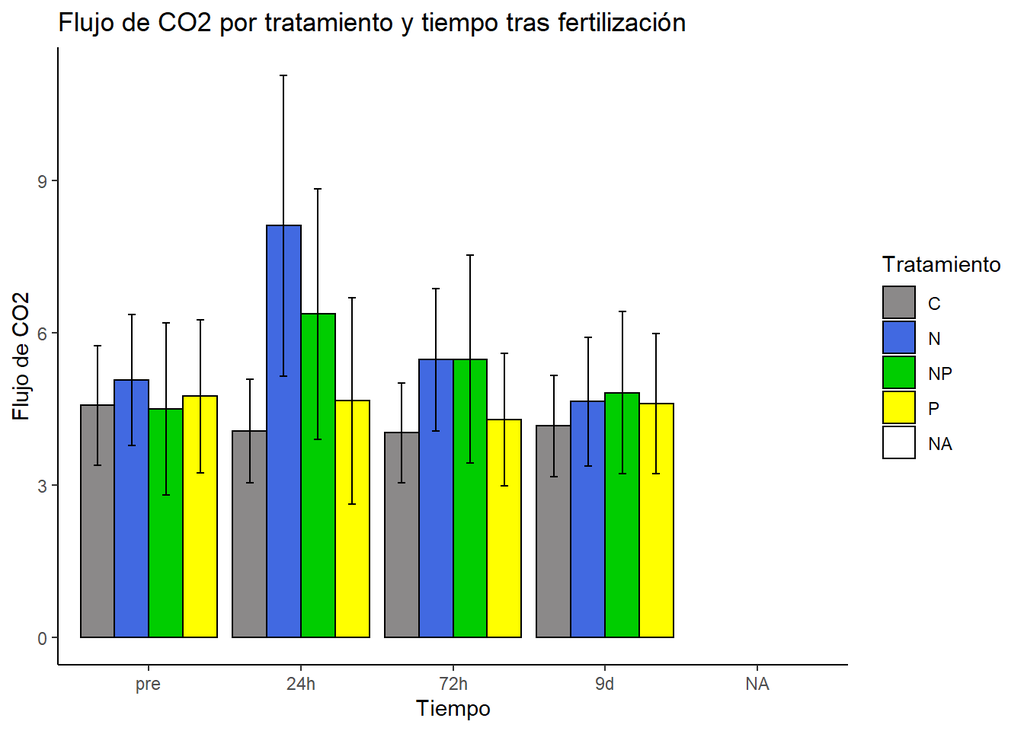

```r
# Cálculo de promedio y desv. est. para cada tratamiento
data_summary <- function(dat1, Flujo_CO2, grp){
  summary_func <- function(x, col){
    c(mean = mean(x[[col]], na.rm=TRUE),
      sd = sd(x[[col]], na.rm=TRUE))
  }
  data_sum <- ddply(dat1, grp, .fun=summary_func,
                  Flujo_CO2)
  data_sum <- rename(data_sum, c("mean" = Flujo_CO2))
 return(data_sum)
}
df2 <- data_summary(dat1, Flujo_CO2="Flujo_CO2",
                    grp=c("Tratamiento", "Tiempo"))

# Gráfico de barras (promedio +/- sd) por tiempo y tratamiento
p <- ggplot(df2, aes(x=Tiempo, y=Flujo_CO2, fill=Tratamiento)) +
  geom_bar(stat="identity", color="black",
           position=position_dodge()) +
  geom_errorbar(aes(ymin=Flujo_CO2-sd, ymax=Flujo_CO2+sd), width=.2,
                 position=position_dodge(.9)) +
  labs(title="Flujo de CO2 por tratamiento y tiempo tras fertilización", x="Tiempo", y = "Flujo de CO2") +
  theme_classic() +
  scale_fill_manual(values=c('snow4','royalblue','green3','yellow','tan'))

# Gráfico de cajas (mediana y cuartiles) por tiempo y tratamiento
q <- ggplot(dat1, aes(x=Tiempo, y=Flujo_CO2, fill=Tratamiento)) +
  geom_boxplot(stat="boxplot", color="black",
           position=position_dodge()) +
  labs(title="Flujo de CO2 por tratamiento y tiempo tras fertilización", x="Tiempo", y = "Flujo de CO2") +
  theme_classic() +
  scale_fill_manual(values=c('snow4','royalblue','green3','yellow','tan'))

p
```

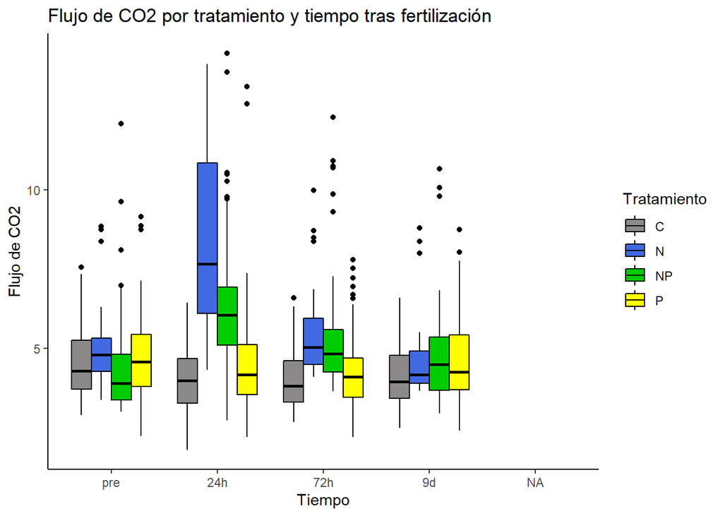

```r
q
```

## Referencias

Alvarez-Clare, Silvia, Michelle C. Mack, and M. Brooks. 2013. “A direct test of nitrogen and phosphorus limitation to net primary productivity in a lowland tropical wet forest.” *Ecology* 94 (7): 1540–51.